# Red Wine Quality Exploration by Fern Liu

# 多变量绘图选择

```
##
##   3   4   5   6   7   8
##  10  53 681 638 199  18
```

```
##    Min. 1st Qu.  Median    Mean 3rd Qu.    Max.
##   3.000   5.000   6.000   5.636   6.000   8.000
```

```
## [1] (4,6] (4,6] (4,6] (4,6] (4,6] (4,6]
## Levels: (2,4] (4,6] (6,8]
```

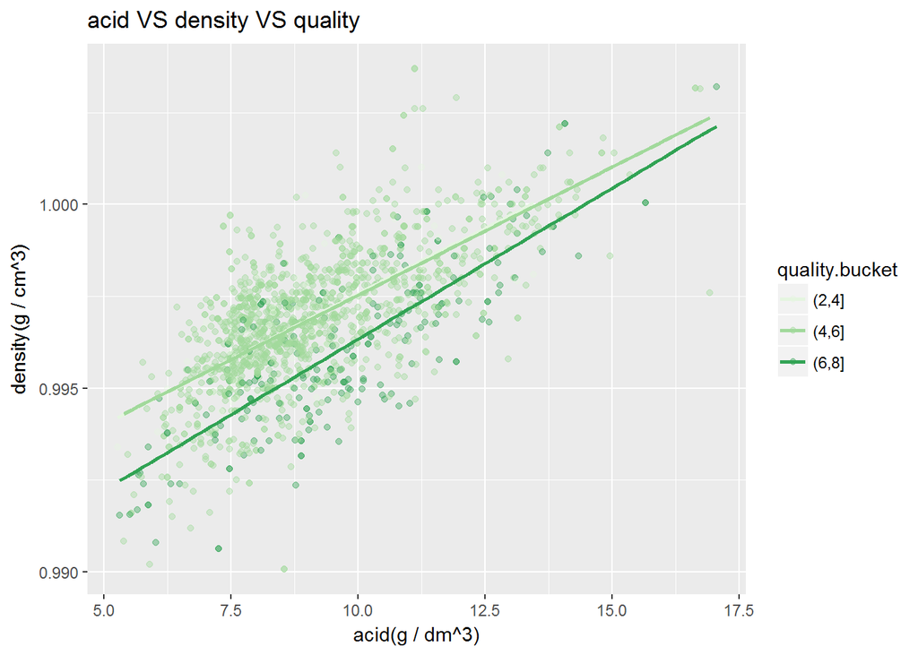

上图可以看出随着酸的含量增多，红酒的密度会增大，而且品质越高的红酒，密度增大会更明显。 那么随着红酒酒精含量的增加，不同品质的红酒密度会如何变化呢？

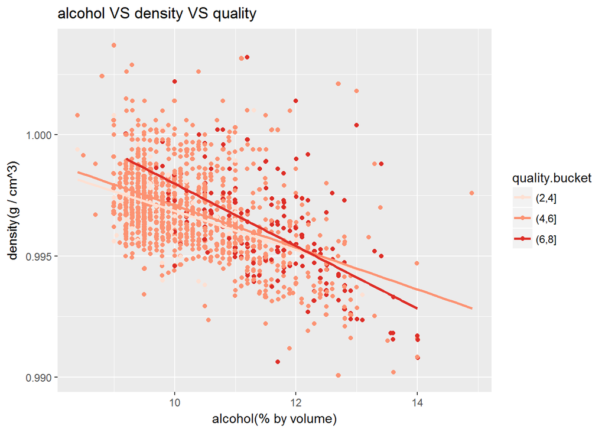

随着红酒酒精含量的增加，红酒密度会减小，而且品质越高的红酒密度下降更明显。 在酒精含量大于12%时，高品质红酒密度会小于低品质红酒密度。 下面看硫酸盐和总二氧化硫对不同品质红酒的密度会有和影响。

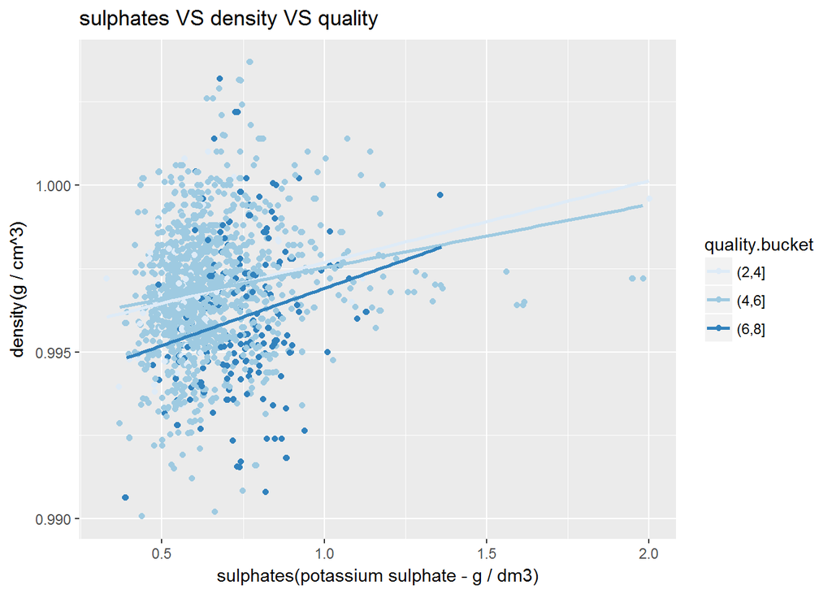

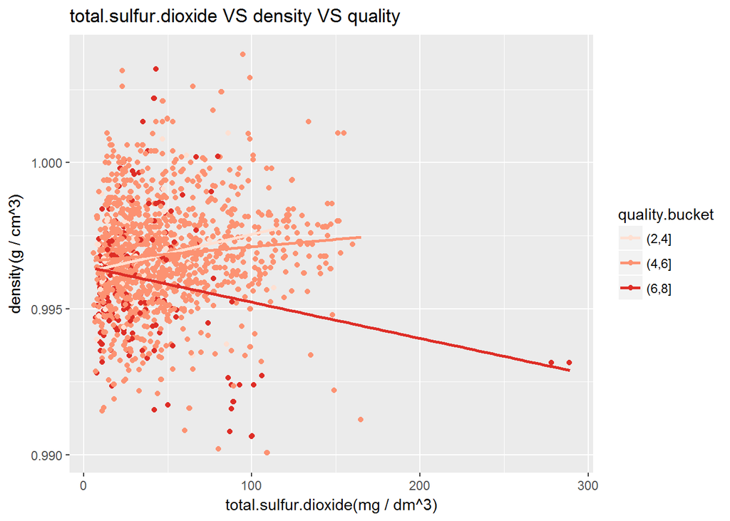

[output not shown]

```
##    Min. 1st Qu.  Median    Mean 3rd Qu.    Max.
##    8.40    9.50   10.20   10.42   11.10   14.90
```

```
##
##     (8,9.5]  (9.5,10.4] (10.4,11.1] (11.1,14.9]
##         436         480         303         380
```